# DSC5103 Assignment 4

Bootstrapping Ridge Regression and LASSO

Tong Wang

Oct 2018

## NOTE:

This assignment is **due at 23:59 of Oct 18, Thursday**. You can work on this file directly and fill in your answers/code below. Please submit the output HTML file (name your file like G1Group02.html if you are from Group 02 of Section G1) onto IVLE/Files/Student Submission/Assignment4 folder.

Also, put the Section/Group and member info below.

```r
# Section A1
# Group 13
# Members: REN JIEWEN, WANG XINRUI, XIAO RUI,LI LIPING
```

### Introduction

In this assignment, we will apply the bootstrap on the regularization models (Ridge Regression and LASSO) we have obtained in Assignment 3 so as to gain better understanding about the variability of the coefficients in the final model.

### Data Preparation

First, let us get the data. We will use the **Heart** data from the textbook, available at http://www-bcf.usc.edu/~gareth/ISL/Heart.csv.

```r
heart <- read.csv(file="http://www-bcf.usc.edu/~gareth/ISL/Heart.csv", row.names=1)
summary(heart)
```

```
##       Age             Sex                ChestPain       RestBP           Chol
##  Min.   :29.00   Min.   :0.0000   asymptomatic:144   Min.   : 94.0   Min.   :126.0
##  1st Qu.:48.00   1st Qu.:0.0000   nonanginal  : 86   1st Qu.:120.0   1st Qu.:211.0
##  Median :56.00   Median :1.0000   nontypical  : 50   Median :130.0   Median :241.0
##  Mean   :54.44   Mean   :0.6799   typical     : 23   Mean   :131.7   Mean   :246.7
##  3rd Qu.:61.00   3rd Qu.:1.0000                      3rd Qu.:140.0   3rd Qu.:275.0
##  Max.   :77.00   Max.   :1.0000                      Max.   :200.0   Max.   :564.0
##
##       Fbs            RestECG           MaxHR           ExAng           Oldpeak         Slope
##  Min.   :0.0000   Min.   :0.0000   Min.   : 71.0   Min.   :0.0000   Min.   :0.00   Min.   :1.000
##  1st Qu.:0.0000   1st Qu.:0.0000   1st Qu.:133.5   1st Qu.:0.0000   1st Qu.:0.00   1st Qu.:1.000
##  Median :0.0000   Median :1.0000   Median :153.0   Median :0.0000   Median :0.80   Median :2.000
##  Mean   :0.1485   Mean   :0.9901   Mean   :149.6   Mean   :0.3267   Mean   :1.04   Mean   :1.601
##  3rd Qu.:0.0000   3rd Qu.:2.0000   3rd Qu.:166.0   3rd Qu.:1.0000   3rd Qu.:1.60   3rd Qu.:2.000
##  Max.   :1.0000   Max.   :2.0000   Max.   :202.0   Max.   :1.0000   Max.   :6.20   Max.   :3.000
##
##        Ca                 Thal      AHD
##  Min.   :0.0000   fixed     : 18   No :164
##  1st Qu.:0.0000   normal    :166   Yes:139
##  Median :0.0000   reversable:117
##  Mean   :0.6722   NA's      :  2
##  3rd Qu.:1.0000
##  Max.   :3.0000
##  NA's   :4
```

The task is to use the features to predict **AHD**, binary outcome related to some heart disease.

Some cleaning is necessary because there are NA’s and also several categorical variables stored as numerical.

```r
# clean the NA's
heart <- na.omit(heart)
# convert to factors
heart$Sex <- as.factor(heart$Sex)
heart$Fbs <- as.factor(heart$Fbs)
heart$RestECG <- as.factor(heart$RestECG)
heart$ExAng <- as.factor(heart$ExAng)
heart$Slope <- as.factor(heart$Slope)
heart$Ca <- as.factor(heart$Ca)
summary(heart)
```

```
##       Age        Sex            ChestPain       RestBP           Chol       Fbs     RestECG
##  Min.   :29.00   0: 96   asymptomatic:142   Min.   : 94.0   Min.   :126.0   0:254   0:147
##  1st Qu.:48.00   1:201   nonanginal  : 83   1st Qu.:120.0   1st Qu.:211.0   1: 43   1:  4
##  Median :56.00           nontypical  : 49   Median :130.0   Median :243.0           2:146
##  Mean   :54.54           typical     : 23   Mean   :131.7   Mean   :247.4
##  3rd Qu.:61.00                              3rd Qu.:140.0   3rd Qu.:276.0
##  Max.   :77.00                              Max.   :200.0   Max.   :564.0
##      MaxHR       ExAng      Oldpeak      Slope   Ca              Thal      AHD
##  Min.   : 71.0   0:200   Min.   :0.000   1:139   0:174   fixed     : 18   No :160
##  1st Qu.:133.0   1: 97   1st Qu.:0.000   2:137   1: 65   normal    :164   Yes:137
##  Median :153.0           Median :0.800   3: 21   2: 38   reversable:115
##  Mean   :149.6           Mean   :1.056           3: 20
##  3rd Qu.:166.0           3rd Qu.:1.600
##  Max.   :202.0           Max.   :6.200
```

Next, we will prepare the training and test dataset for later model comparison.

```r
# split training and test data 50/50
N <- nrow(heart)
N.train <- round(N/2)
set.seed(456)
train.index <- sample(1:N, N.train)
data.train <- heart[train.index, ]
data.test <- heart[- train.index,]
```

### Questions and Answers

#### 1. [Single Ridge Regression & LASSO] Fit a Ridge Regression model on the training data, use the optimal $\lambda$ we obtained last time ($\lambda = 0.0402$), and print the coefficients of the optimal model. Fit a LASSO model on the training data, use the optimal $\lambda$ we obtained last time ($\lambda = 0.0186$), and print the coefficients of the the optimal model. (1 Mark)

Answer:

```r
library("glmnetUtils")
# Ridge Regression model
ridge <- glmnet(AHD ~ ., data.train,family="binomial",alpha=0,lambda = 0.0402, use.model.frame=TRUE)
# print the coefficients of the optimal model
coef(ridge)
```

```
## 21 x 1 sparse Matrix of class "dgCMatrix"
##                               s0
## (Intercept)         -2.423546212
## Age                 -0.016274171
## Sex1                 0.736638461
## ChestPainnonanginal -0.868479852
## ChestPainnontypical -0.012035908
## ChestPaintypical    -0.058077171
## RestBP               0.028133730
## Chol                 0.002272635
## Fbs1                 0.008581646
## RestECG1             0.034498838
## RestECG2             0.231171162
## MaxHR               -0.021621405
## ExAng1               0.614432297
## Oldpeak              0.296414211
## Slope2               1.002277586
## Slope3               0.323636733
## Ca1                  1.360690416
## Ca2                  1.708782591
## Ca3                  1.121883713
## Thalnormal          -0.340151757
## Thalreversable       0.967307547
```

```r
# LASSO model
lasso <- glmnet(AHD ~ .,data.train, family="binomial",alpha=1,lambda = 0.0186, use.model.frame=TRUE)
# print the coefficients of the optimal model
coef(lasso)
```

```
## 21 x 1 sparse Matrix of class "dgCMatrix"
##                                s0
## (Intercept)         -3.3923992926
## Age                 -0.0002238916
## Sex1                 0.7102353946
## ChestPainnonanginal -0.8763725370
## ChestPainnontypical  .
## ChestPaintypical     .
## RestBP               0.0295767965
## Chol                 0.0004023317
## Fbs1                 .
## RestECG1             .
## RestECG2             0.0244801437
## MaxHR               -0.0207520946
## ExAng1               0.4975906066
## Oldpeak              0.3379700558
## Slope2               1.0390193487
## Slope3               .
## Ca1                  1.3703749282
## Ca2                  1.7175107075
## Ca3                  0.8051083129
## Thalnormal           .
## Thalreversable       1.3489941441
```

#### 2. [Bootstrap] Generate $B=500$ bootstrap samples from the training data. For each bootstrap sample, fit the Ridge Regression and LASSO models using there respective optimal lambda (as specified above), and keep a record of the models’ coefficients. (2 Marks)

Answer:

```r
set.seed(456)
B <- 500

#Create 2 empty data frame to collect the coefficients of the model

#Extract names from coefficient of the models
dimnames <- dimnames(coef(ridge))[[1]]
dimnames[1] = "Intercept"

coef_ridge <- setNames(as.data.frame(matrix(nrow = B, ncol = nrow(coef(ridge))[[1]])),dimnames)
coef_lasso <- setNames(as.data.frame(matrix(nrow = B, ncol = nrow(coef(lasso))[[1]])),dimnames)

# Run the bootstrap models
for(i in 1:B){
  n_samples <- nrow(data.train)
  sample_row_ids <- sample(1:n_samples,n_samples, replace=TRUE)
  new.data.train <- data.train[sample_row_ids, ]
  ridge_boot <- glmnet(AHD ~ ., new.data.train,family="binomial",alpha=0,lambda = 0.0402, use.model.frame=TRUE)
  coef_ridge[i,] <- coef(ridge_boot)
  lasso_boot <- glmnet(AHD ~ .,new.data.train, family="binomial",alpha=1,lambda = 0.0186, use.model.frame=TRUE)
  coef_lasso[i,] <- coef(lasso_boot)
}
```

#### 3. Plot the distributions (across the 500 bootstrap runs) of the intercept and the coefficients with respect to the following predictors: Age, MaxHR, and ThalNormal. How can we use these distributions? (2 Marks)

Answer:

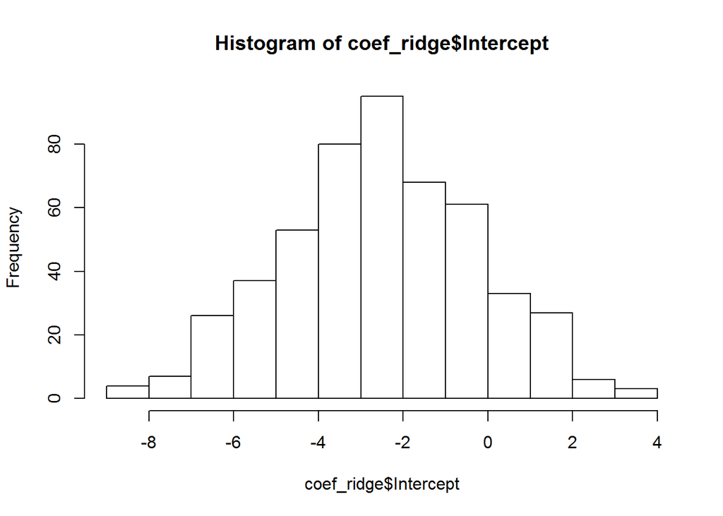

```r
#Ridge models
hist(coef_ridge$Intercept)
```

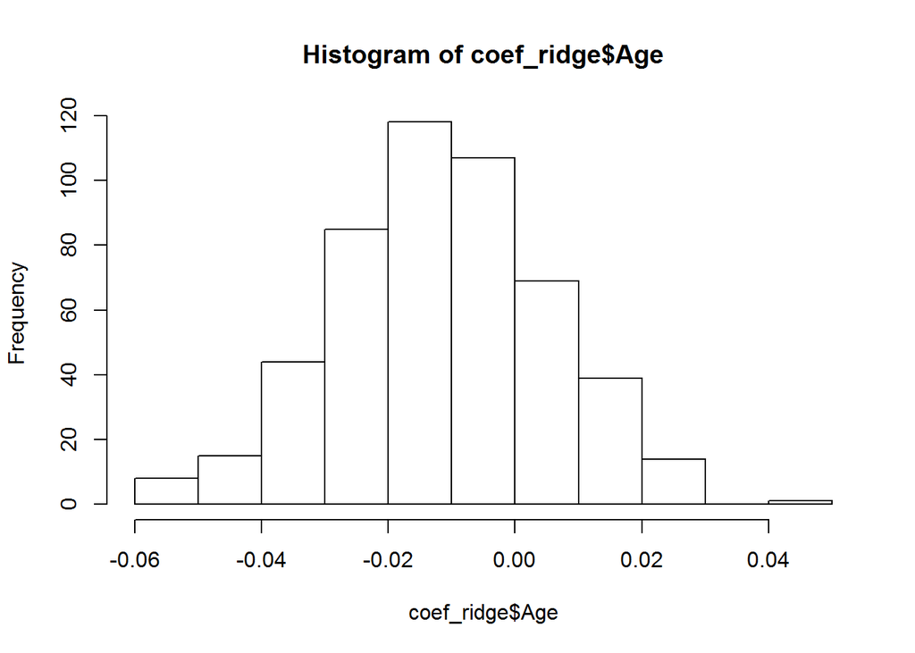

```r
hist(coef_ridge$Age)
```

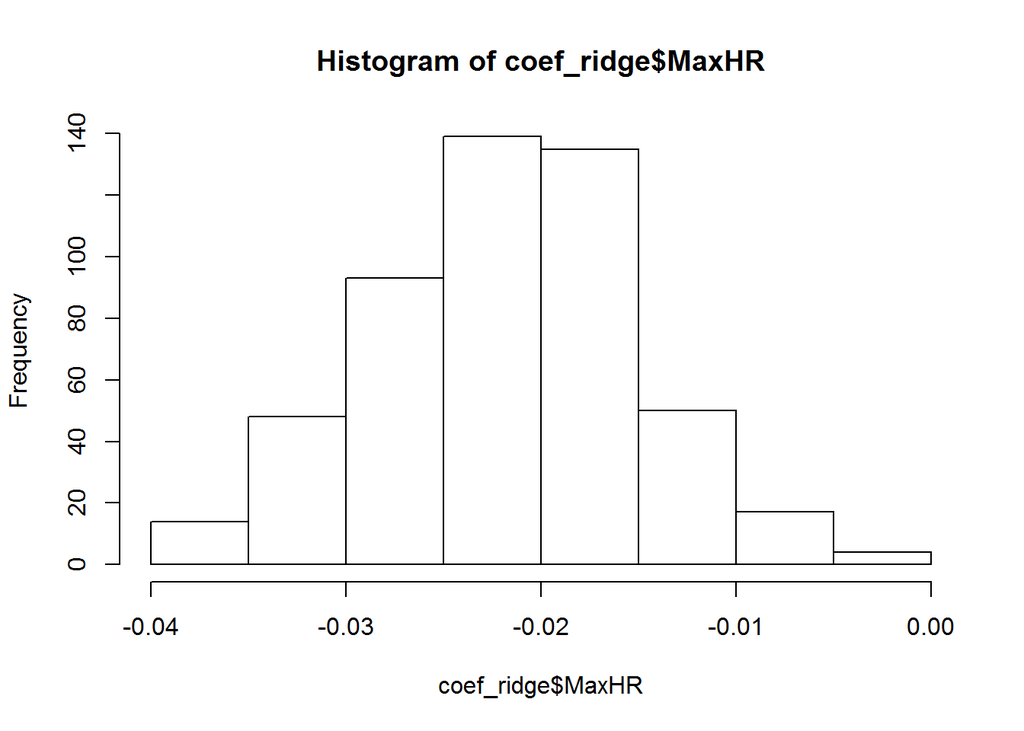

```r
hist(coef_ridge$MaxHR)
```

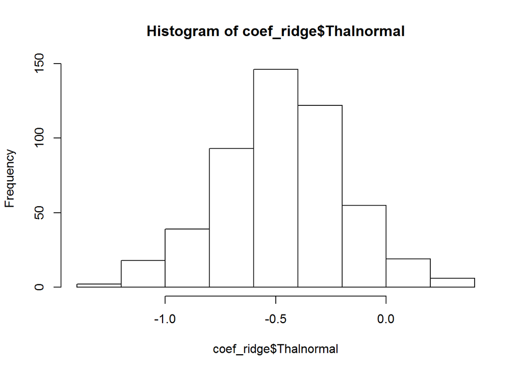

```r
hist(coef_ridge$Thalnormal)
```

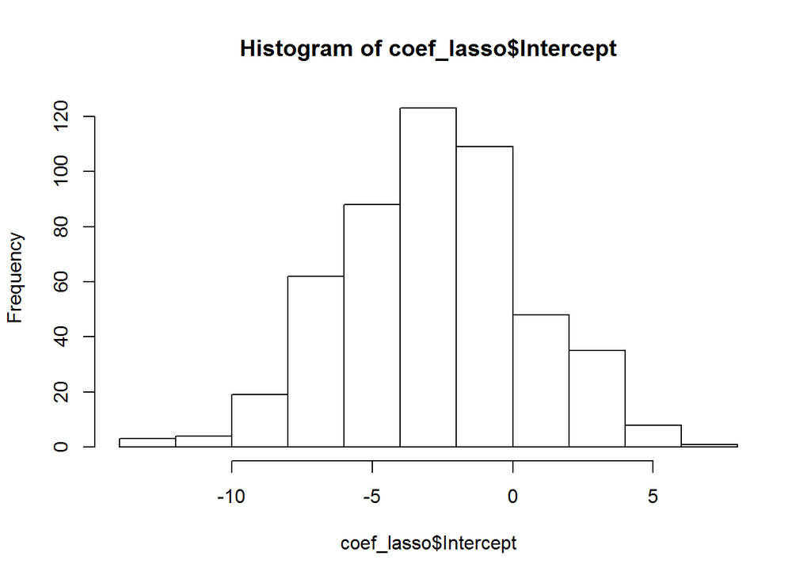

```r
#Lasso models
hist(coef_lasso$Intercept)
```

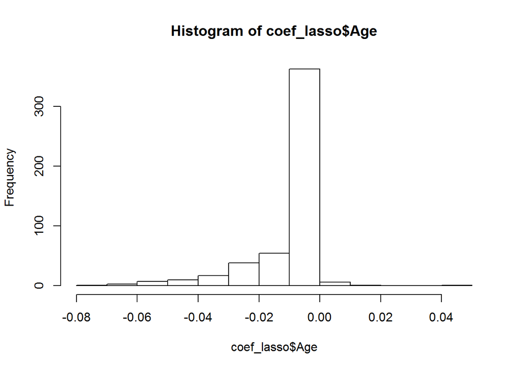

```r
hist(coef_lasso$Age)
```

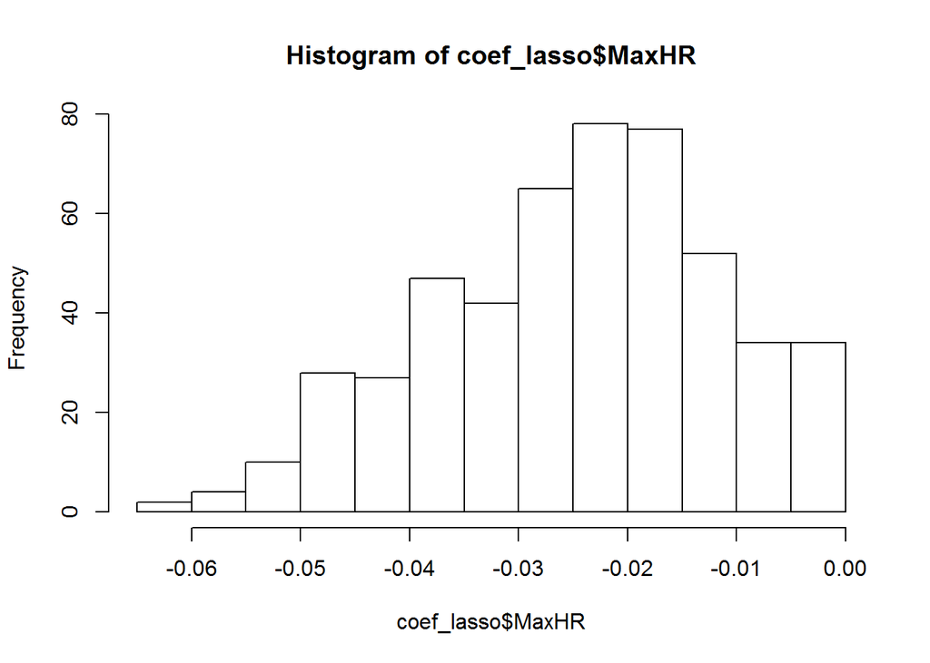

```r
hist(coef_lasso$MaxHR)
```

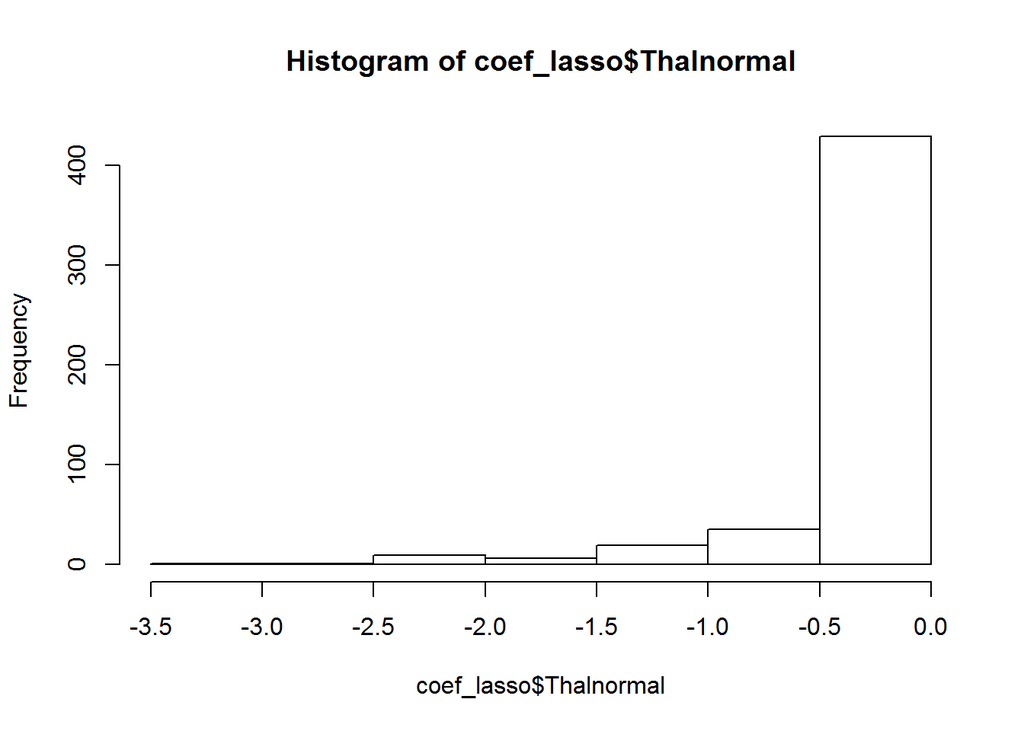

```r
hist(coef_lasso$Thalnormal)
```

### Usually we don’t know the whole population and can only research on a sample from the population, which probably has different statistics. When we use ensamble method and sample in the sample over times, although the mean of the sample mean can still be different, the deviation will be close to the true deviation of the population, from which we can generate reliable confidence interval and hypothesis testing.